# neuro-521-gilmore-2015-01-21

2016-01-20 14:11:43

## 2015-01-21 – Studying human brain function through fMRI

1. How does fMRI work? What does it measure?
2. How do "functional" maps of the cerebral cortex derived from fMRI relate to maps derived from other methods?
3. How are fMRI-based maps actually created?

## Readings

**DeYoe, E. A., Bandettini, P., Neitz, J., Miller, D., & Winans, P. (1994). Functional magnetic resonance imaging (FMRI) of the human brain. Journal of Neuroscience Methods, 54(2), 171–187. http://doi.org/10.1016/0165-0270(94)90191-0**

Rosen, B. R., Buckner, R. L., & Dale, A. M. (1998). Event-related functional MRI: Past, present, and future. Proceedings of the National Academy of Sciences of the United States of America, 95(3), 773–780. http://www.pnas.org/content/95/3/773.full#content-block

## Supplemental

Warnking, J., Dojat, M., Guérin-Dugué, A., Delon-Martin, C., Olympieff, S., Richard, N., … Segebarth, C. (2002). fMRI Retinotopic Mapping—Step by Step. NeuroImage, 17(4), 1665–1683. http://doi.org/10.1006/nimg.2002.1304

[Magnetic Resonance Imaging Explained](https://www.youtube.com/watch?v=MiL0wCZr0Mw)

## Why MRI?

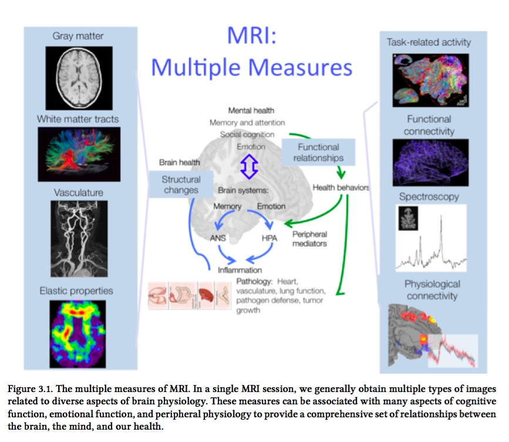

## Historical background

- (Roy and Sherrington 1890), local changes in blood volume in cerebral cortex.
- (Kety and Schmidt 1945), regional regulation of blood flow in brain.
- First fMRI paper [(Ogawa et al. 1990)](http://www.pnas.org/content/87/24/9868).
- Early fMRI paper by a competing group: [(Kwong et al. 1992)](http://doi.org/10.1073/pnas.89.12.5675)

## Scan components/types

- Structural
  - e.g., MP-RAGE (Magnetization Prepared Rapid Acquisition Gradient Echo)
    - High resolution (.5-1 mm^3 voxels)
  - Diffusion Tensor Imaging (DTI)
- Functional
  - Blood oxygen level dependent (BOLD) imaging
    - Lower resolution (3 mm^3 voxels)

## Blood Oxygen Level Dependent (BOLD) imaging

- Local changes in blood oxygen
  - Blood volume + O2
- Oxygenated vs. deoxygenated hemoglobin (Hb)
  - Oxygenated Hb [diamagnetic](https://en.wikipedia.org/wiki/Diamagnetism)
  - De-oxygenated Hb [paramagnetic](https://en.wikipedia.org/wiki/Paramagnetism)

## [Hemodynamic response function (HRF)](https://en.wikipedia.org/wiki/Haemodynamic_response)

- Initial O2 dip
- Longer increase to peak 4-8s, then decline

## HRF illustrated

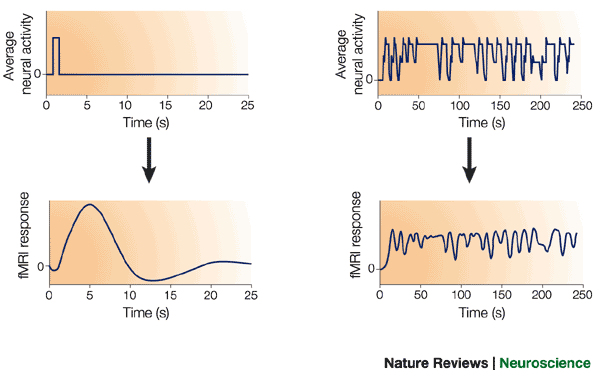

[(Heeger and Ress 2002)](http://doi.org/10.1038/nrn730)

## How do neurons change blood flow?

- What are mechanisms of [neurovascular coupling](http://www.scholarpedia.org/article/Neurovascular_coupling).
- Precapillary smooth muscle cells contraction (Hill et al. 2015).

[figure not shown]

## BOLD vs. other measures of neuronal activity

- [(Logothetis et al. 2001)](http://doi.org/10.1038/35084005)

## Data analysis pathway

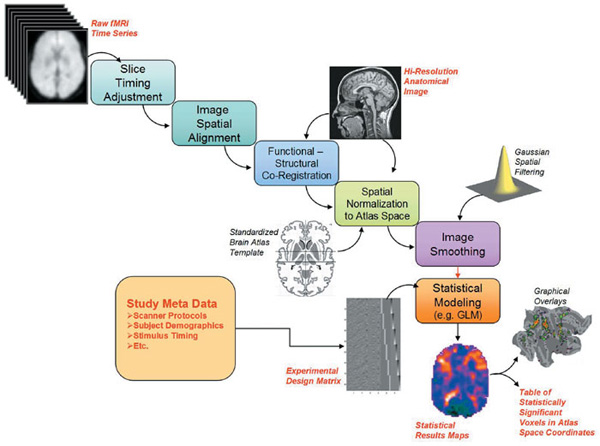

(Horn et al. 2004)

## Data analysis pathway

- Convert raw (\(k\)-space/2d frequency domain) maps using inverse FFT
- Adjust "timing" of slices (e.g., 30 "slices" in 2s)
- Align BOLD images with one another; calculate movement
- Register individual structural image with BOLD image time series

## Data analysis pathway

- Normalize individual structural image with template atlas
- Use fitted normalization parameters on BOLD images
- Smooth BOLD images

## Data analysis pathway

- Statistical modeling using voxel-wise GLM
  - At individual level
    - Condition vs. baseline/error.
  - At group level

## Types of maps (Lindquist and Wager 2015)

- Effects of experimental manipulations
- Correlations with behavior, clinical status, or other person-level outcomes
- Correlations with performance or other within-person variables
- Brain areas’ correlation with other specific areas
- Brain areas’ that are part of a group of areas (e.g. a cluster or network)

## Single-subject vs. Group maps

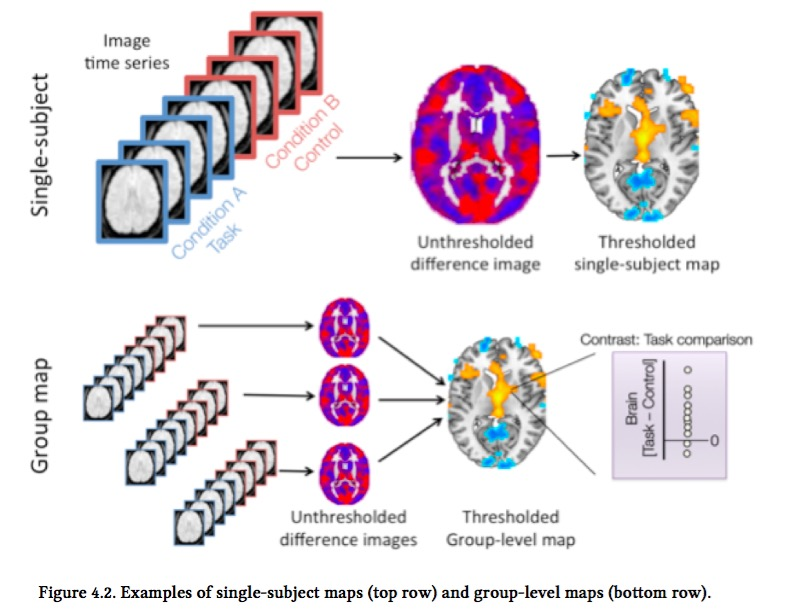

(Lindquist and Wager 2015)

## Underlying assumptions

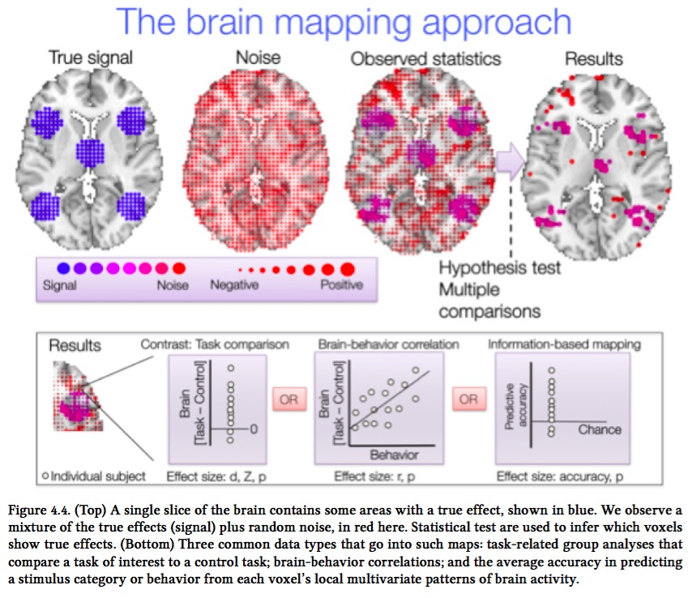

(Lindquist and Wager 2015)

## Be careful out there

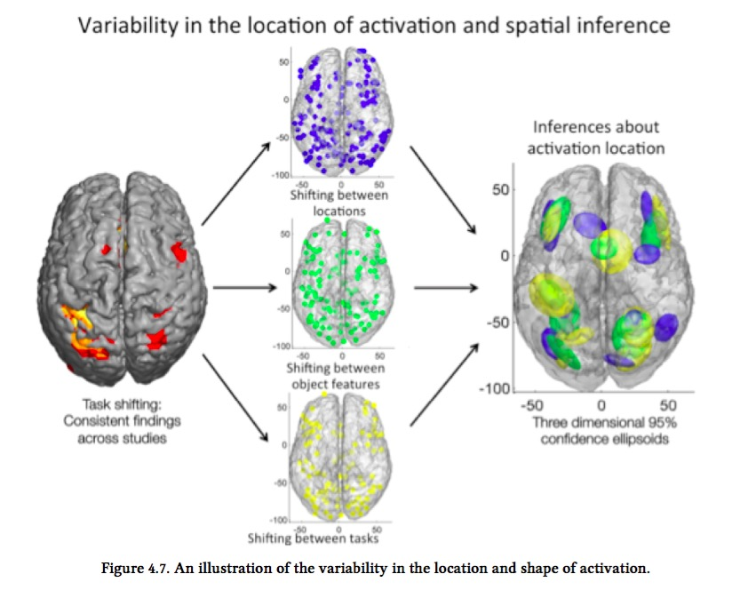

(Lindquist and Wager 2015)

## Seven Caveats in Brain Map Inferences (Lindquist and Wager 2015)

- Not significant does not mean not important
- Maps are noisy
- We cannot infer the size of the effects in significant regions
- Maps are relative comparisons

## Seven Caveats in Brain Map Inferences (Lindquist and Wager 2015)

- Significant does not mean causal
- Statistically stronger does not mean more important
- Anatomical localization is imprecise

## Challenges in controlling for multiple comparisons

- Number of active voxels AND sizes of voxel clusters.
- Many conventional techniques for controlling cluster-level \(p\) values show inflated Type I (false positive) errors, [(Eklund, Nichols, and Knutsson 2015)](http://arxiv.org/abs/1511.01863)

## Most neuroscience studies are underpowered

- [(Button et al. 2013)](http://doi.org/10.1038/nrn3475)
- [Reproducible neuroscience](http://reproducibility.stanford.edu)

## Toward open, reproducible neuroscience

- [Neurosynth](http://neurosynth.org/)
- [OpenfMRI.org](https://openfmri.org)
- [Brain Imaging Data Structure](http://bids.neuroimaging.io)

## 'Big data' and neuroimaging

- [Human Connectome Project](http://www.humanconnectomeproject.org)
- [(Poldrack et al. 2015)](http://doi.org/10.1038/ncomms9885)

## Multivoxel Pattern Analysis (MVPA)

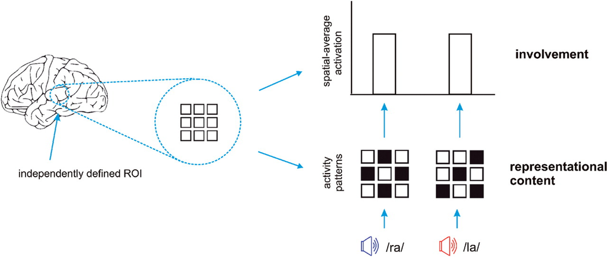

[(Mur, Bandettini, and Kriegeskorte 2009)](http://doi.org/10.1093/scan/nsn044)

## References

Button, Katherine S., John P. A. Ioannidis, Claire Mokrysz, Brian A. Nosek, Jonathan Flint, Emma S. J. Robinson, and Marcus R. Munafò. 2013. “Power Failure: Why Small Sample Size Undermines the Reliability of Neuroscience.” *Nature Reviews Neuroscience* 14 (5): 365–76. doi:10.1038/nrn3475.

Eklund, Anders, Thomas Nichols, and Hans Knutsson. 2015. “Can Parametric Statistical Methods Be Trusted for fMRI Based Group Studies?” *ArXiv:1511.01863 [Math, Stat]*, November. http://arxiv.org/abs/1511.01863.

Heeger, David J., and David Ress. 2002. “What Does fMRI Tell Us About Neuronal Activity?” *Nature Reviews Neuroscience* 3 (2): 142–51. doi:10.1038/nrn730.

Hill, Robert A., Lei Tong, Peng Yuan, Sasidhar Murikinati, Shobhana Gupta, and Jaime Grutzendler. 2015. “Regional Blood Flow in the Normal and Ischemic Brain Is Controlled by Arteriolar Smooth Muscle Cell Contractility and Not by Capillary Pericytes.” *Neuron* 87 (1): 95–110. doi:10.1016/j.neuron.2015.06.001.

Horn, John Darrell Van, Scott T. Grafton, Daniel Rockmore, and Michael S. Gazzaniga. 2004. “Sharing Neuroimaging Studies of Human Cognition.” *Nature Neuroscience* 7 (5): 473–81. doi:10.1038/nn1231.

Kety, Seymour S, and Carl F Schmidt. 1945. “THE DETERMINATION oF CEREBRAL BLOOD FLOW iN MAN bY tHE-USE oF NITROUS OXIDE iN LOW CONCENTRATTONS.” *American Journal of Physiology* 143: 53–66.

Kwong, K. K., J. W. Belliveau, D. A. Chesler, I. E. Goldberg, R. M. Weisskoff, B. P. Poncelet, D. N. Kennedy, B. E. Hoppel, M. S. Cohen, and R. Turner. 1992. “Dynamic Magnetic Resonance Imaging of Human Brain Activity During Primary Sensory Stimulation.” *Proceedings of the National Academy of Sciences* 89 (12): 5675–79. doi:10.1073/pnas.89.12.5675.

Lindquist, Michael, and Tor Wager. 2015. *Principles of FMRI*. Leanpub.com. http://leanpub.com/principlesoffmri.

Logothetis, Nikos K., Jon Pauls, Mark Augath, Torsten Trinath, and Axel Oeltermann. 2001. “Neurophysiological Investigation of the Basis of the fMRI Signal.” *Nature* 412 (6843): 150–57. doi:10.1038/35084005.

Mur, Marieke, Peter A. Bandettini, and Nikolaus Kriegeskorte. 2009. “Revealing Representational Content with Pattern-Information fMRI—an Introductory Guide.” *Social Cognitive and Affective Neuroscience* 4 (1): 101–9. doi:10.1093/scan/nsn044.

Ogawa, S., T. M. Lee, A. R. Kay, and D. W. Tank. 1990. “Brain Magnetic Resonance Imaging with Contrast Dependent on Blood Oxygenation.” *Proceedings of the National Academy of Sciences* 87 (24): 9868–72. http://www.pnas.org/content/87/24/9868.

Poldrack, Russell A., Timothy O. Laumann, Oluwasanmi Koyejo, Brenda Gregory, Ashleigh Hover, Mei-Yen Chen, Krzysztof J. Gorgolewski, et al. 2015. “Long-Term Neural and Physiological Phenotyping of a Single Human.” *Nature Communications* 6 (December): 8885. doi:10.1038/ncomms9885.

Roy, Charles Smart, and Charles S Sherrington. 1890. “On the Regulation of the Blood-Supply of the Brain.” *The Journal of Physiology* 11 (1-2). Wiley Online Library: 85–158.